# LDA, QDA and Multinomial Logistic Regression

Phoebe Tan

2023-08-26

## Preprocessing data

```r
#Data from https://www.kaggle.com/datasets/jmcaro/wheat-seedsuci
data= read.csv("seeds.csv")
str(data)
```

```
## 'data.frame':    199 obs. of  8 variables:
##  $ Area           : num  15.3 14.9 14.3 13.8 16.1 ...
##  $ Perimeter      : num  14.8 14.6 14.1 13.9 15 ...
##  $ Compactness    : num  0.871 0.881 0.905 0.895 0.903 ...
##  $ Kernel.Length  : num  5.76 5.55 5.29 5.32 5.66 ...
##  $ Kernel.Width   : num  3.31 3.33 3.34 3.38 3.56 ...
##  $ Asymmetry.Coeff: num  2.22 1.02 2.7 2.26 1.35 ...
##  $ Kernel.Groove  : num  5.22 4.96 4.83 4.8 5.17 ...
##  $ Type           : int  1 1 1 1 1 1 1 1 1 1 ...
```

```r
head(data)
```

```
##    Area Perimeter Compactness Kernel.Length Kernel.Width Asymmetry.Coeff
## 1 15.26     14.84      0.8710         5.763        3.312           2.221
## 2 14.88     14.57      0.8811         5.554        3.333           1.018
## 3 14.29     14.09      0.9050         5.291        3.337           2.699
## 4 13.84     13.94      0.8955         5.324        3.379           2.259
## 5 16.14     14.99      0.9034         5.658        3.562           1.355
## 6 14.38     14.21      0.8951         5.386        3.312           2.462
##   Kernel.Groove Type
## 1         5.220    1
## 2         4.956    1
## 3         4.825    1
## 4         4.805    1
## 5         5.175    1
## 6         4.956    1
```

```r
unique(data$Type) #Target Output: Type of Wheat seeds- 1,2,3
```

```
## [1] 1 2 3
```

```r
library(dplyr)
data= data %>% mutate(id=1:nrow(data))
train<- data %>% dplyr::sample_frac(0.7)
test  <- dplyr::anti_join(data, train, by = 'id')
write.csv(train, file= "train.csv",quote=F,row.names=F,col.names=T)
write.csv(test, file= "test.csv",quote=F,row.names=F,col.names=T)
Q4train=read.table("train.csv",sep = ",",header = T)
Q4test=read.table("test.csv",sep = ",",header = T)
```

# Reading Dataset

```r
#Remove ID columns
Q4train=subset(Q4train,select=-c(id))
Q4test=subset(Q4test,select=-c(id))

#Read data
head(Q4train)
```

```
##    Area Perimeter Compactness Kernel.Length Kernel.Width Asymmetry.Coeff
## 1 16.84     15.67      0.8623         5.998        3.484           4.675
## 2 10.80     12.57      0.8590         4.981        2.821           4.773
## 3 16.16     15.33      0.8644         5.845        3.395           4.266
## 4 12.15     13.45      0.8443         5.417        2.837           3.638
## 5 15.11     14.54      0.8986         5.579        3.462           3.128
## 6 13.74     14.05      0.8744         5.482        3.114           2.932
##   Kernel.Groove Type
## 1         5.877    2
## 2         5.063    3
## 3         5.795    2
## 4         5.338    3
## 5         5.180    1
## 6         4.825    1
```

```r
head(Q4test)
```

```
##    Area Perimeter Compactness Kernel.Length Kernel.Width Asymmetry.Coeff
## 1 14.88     14.57      0.8811         5.554        3.333           1.018
## 2 14.29     14.09      0.9050         5.291        3.337           2.699
## 3 13.84     13.94      0.8955         5.324        3.379           2.259
## 4 16.14     14.99      0.9034         5.658        3.562           1.355
## 5 14.38     14.21      0.8951         5.386        3.312           2.462
## 6 16.63     15.46      0.8747         6.053        3.465           2.040
##   Kernel.Groove Type
## 1         4.956    1
## 2         4.825    1
## 3         4.805    1
## 4         5.175    1
## 5         4.956    1
## 6         5.877    1
```

```r
# Finding the unique value in the dataset
unique(Q4train$Type)
```

```
## [1] 2 3 1
```

```r
# Finding NA or missing vales in the dataset
is.na(Q4train$Type)
```

```
##   [1] FALSE FALSE FALSE FALSE FALSE FALSE FALSE FALSE FALSE FALSE FALSE FALSE
##  [13] FALSE FALSE FALSE FALSE FALSE FALSE FALSE FALSE FALSE FALSE FALSE FALSE
##  [25] FALSE FALSE FALSE FALSE FALSE FALSE FALSE FALSE FALSE FALSE FALSE FALSE
##  [37] FALSE FALSE FALSE FALSE FALSE FALSE FALSE FALSE FALSE FALSE FALSE FALSE
##  [49] FALSE FALSE FALSE FALSE FALSE FALSE FALSE FALSE FALSE FALSE FALSE FALSE
##  [61] FALSE FALSE FALSE FALSE FALSE FALSE FALSE FALSE FALSE FALSE FALSE FALSE
##  [73] FALSE FALSE FALSE FALSE FALSE FALSE FALSE FALSE FALSE FALSE FALSE FALSE
##  [85] FALSE FALSE FALSE FALSE FALSE FALSE FALSE FALSE FALSE FALSE FALSE FALSE
##  [97] FALSE FALSE FALSE FALSE FALSE FALSE FALSE FALSE FALSE FALSE FALSE FALSE
## [109] FALSE FALSE FALSE FALSE FALSE FALSE FALSE FALSE FALSE FALSE FALSE FALSE
## [121] FALSE FALSE FALSE FALSE FALSE FALSE FALSE FALSE FALSE FALSE FALSE FALSE
## [133] FALSE FALSE FALSE FALSE FALSE FALSE FALSE
```

```r
sum(is.na(Q4train$Type))
```

```
## [1] 0
```

There are 3 unique values of the type of seeds- 1,2 and 3. There are no NA values.

```r
#Finding missing values of both dataset togther
for(i in 1:8)
{
Q4train<-Q4train[!is.na(Q4train[,i]),]
Q4test<-Q4test[!is.na(Q4test[,i]),]
}
head(Q4train)
```

```
##    Area Perimeter Compactness Kernel.Length Kernel.Width Asymmetry.Coeff
## 1 16.84     15.67      0.8623         5.998        3.484           4.675
## 2 10.80     12.57      0.8590         4.981        2.821           4.773
## 3 16.16     15.33      0.8644         5.845        3.395           4.266
## 4 12.15     13.45      0.8443         5.417        2.837           3.638
## 5 15.11     14.54      0.8986         5.579        3.462           3.128
## 6 13.74     14.05      0.8744         5.482        3.114           2.932
##   Kernel.Groove Type
## 1         5.877    2
## 2         5.063    3
## 3         5.795    2
## 4         5.338    3
## 5         5.180    1
## 6         4.825    1
```

```r
head(Q4test)
```

```
##    Area Perimeter Compactness Kernel.Length Kernel.Width Asymmetry.Coeff
## 1 14.88     14.57      0.8811         5.554        3.333           1.018
## 2 14.29     14.09      0.9050         5.291        3.337           2.699
## 3 13.84     13.94      0.8955         5.324        3.379           2.259
## 4 16.14     14.99      0.9034         5.658        3.562           1.355
## 5 14.38     14.21      0.8951         5.386        3.312           2.462
## 6 16.63     15.46      0.8747         6.053        3.465           2.040
##   Kernel.Groove Type
## 1         4.956    1
## 2         4.825    1
## 3         4.805    1
## 4         5.175    1
## 5         4.956    1
## 6         5.877    1
```

```r
str(Q4train)
```

```
## 'data.frame':    139 obs. of  8 variables:
##  $ Area           : num  16.8 10.8 16.2 12.2 15.1 ...
##  $ Perimeter      : num  15.7 12.6 15.3 13.4 14.5 ...
##  $ Compactness    : num  0.862 0.859 0.864 0.844 0.899 ...
##  $ Kernel.Length  : num  6 4.98 5.84 5.42 5.58 ...
##  $ Kernel.Width   : num  3.48 2.82 3.4 2.84 3.46 ...
##  $ Asymmetry.Coeff: num  4.67 4.77 4.27 3.64 3.13 ...
##  $ Kernel.Groove  : num  5.88 5.06 5.79 5.34 5.18 ...
##  $ Type           : int  2 3 2 3 1 1 3 1 2 1 ...
```

```r
str(Q4test)
```

```
## 'data.frame':    60 obs. of  8 variables:
##  $ Area           : num  14.9 14.3 13.8 16.1 14.4 ...
##  $ Perimeter      : num  14.6 14.1 13.9 15 14.2 ...
##  $ Compactness    : num  0.881 0.905 0.895 0.903 0.895 ...
##  $ Kernel.Length  : num  5.55 5.29 5.32 5.66 5.39 ...
##  $ Kernel.Width   : num  3.33 3.34 3.38 3.56 3.31 ...
##  $ Asymmetry.Coeff: num  1.02 2.7 2.26 1.35 2.46 ...
##  $ Kernel.Groove  : num  4.96 4.83 4.8 5.17 4.96 ...
##  $ Type           : int  1 1 1 1 1 1 1 1 1 1 ...
```

### Table function (table())in R performs a tabulation of categorical variable and gives its frequency as output.

```r
unique(Q4train$Type)
```

```
## [1] 2 3 1
```

```r
table(Q4train$Type)
```

```
##
##  1  2  3
## 40 47 52
```

There are 3 unique values and the data seems evenly spread across the different types of seeds.

## LDA (Linear Discriminant Analysis) :

```r
## LDA for Type of seeds
#Package
library(MASS)
unique(Q4train$Type)
```

```
## [1] 2 3 1
```

```r
#model
lda_model <- lda(Type~ . ,data = Q4train)
lda_model
```

```
## Call:
## lda(Type ~ ., data = Q4train)
##
## Prior probabilities of groups:
##         1         2         3
## 0.2877698 0.3381295 0.3741007
##
## Group means:
##       Area Perimeter Compactness Kernel.Length Kernel.Width Asymmetry.Coeff
## 1 14.39850  14.34800   0.8775300      5.544675     3.239500        2.688753
## 2 18.56021  16.24553   0.8824000      6.202957     3.693234        3.735809
## 3 11.80865  13.22481   0.8476865      5.229654     2.839462        4.795404
##   Kernel.Groove
## 1      5.116175
## 2      6.064064
## 3      5.121385
##
## Coefficients of linear discriminants:
##                        LD1         LD2
## Area            -0.4746294   4.1582683
## Perimeter        3.2122820  -8.5388363
## Compactness      5.4310892 -82.7204648
## Kernel.Length   -5.0319558  -6.6208837
## Kernel.Width     1.4645165   0.1843928
## Asymmetry.Coeff -0.1049409   0.3009430
## Kernel.Groove    3.5221018   6.7364843
##
## Proportion of trace:
##    LD1    LD2
## 0.7401 0.2599
```

## Assess the accuracy of the prediction using the independent testing set

```r
#Predict:-It returns the classification and the posterior probabilities of the new data based on the Linear Discriminant model.

##Predict category
library(dplyr)

lda_result <- predict(lda_model,Q4test[,-8])$class

#Confusion matrix
ans <- lda_result == Q4test$target
test_result_lda <- length(which(ans == TRUE))/nrow(Q4test)
cat("Confusion table of LDA:")
```

```
## Confusion table of LDA:
```

```r
result=table(lda_result,Q4test[,8]);result
```

```
##
## lda_result  1  2  3
##          1 25  0  1
##          2  1 21  0
##          3  0  0 12
```

```r
# Total percent correct from the testing set
accuracy=sum(diag(result))/nrow(Q4test);accuracy
```

```
## [1] 0.9666667
```

The accuracy of predicting the type of wheat seed is high, at 96.7%

## Quadratic Discriminant Analysis (QDA)

#### QDA for Type

```r
#model
qda_model <- qda(Type~.,data = Q4train)
qda_model
```

```
## Call:
## qda(Type ~ ., data = Q4train)
##
## Prior probabilities of groups:
##         1         2         3
## 0.2877698 0.3381295 0.3741007
##
## Group means:
##       Area Perimeter Compactness Kernel.Length Kernel.Width Asymmetry.Coeff
## 1 14.39850  14.34800   0.8775300      5.544675     3.239500        2.688753
## 2 18.56021  16.24553   0.8824000      6.202957     3.693234        3.735809
## 3 11.80865  13.22481   0.8476865      5.229654     2.839462        4.795404
##   Kernel.Groove
## 1      5.116175
## 2      6.064064
## 3      5.121385
```

#Predicting the Qda using the test data

```r
########Predict Type
qda_result <- predict(qda_model,Q4test[,-8])$class

##############confusion matrix
ans <- qda_result == Q4test$Type
test_result_qda <- length(which(ans == TRUE))/nrow(Q4test)
cat("Confusion table of QDA:")
```

```
## Confusion table of QDA:
```

```r
result=table(qda_result,Q4test[,8]);result
```

```
##
## qda_result  1  2  3
##          1 22  2  1
##          2  2 19  0
##          3  2  0 12
```

```r
###Accuracy
# Total percent correct from the testing set
accuracy=sum(diag(result))/nrow(Q4test);accuracy
```

```
## [1] 0.8833333
```

The accuracy for QDA is lower than that of LDA, at 88.3%.

# Multinomial Logistic Regression

## Data preprocessing

For this, I chose to predict with chosen variables: Area, Compactness, Kernel.Width and Kernel.Groove. The reason for removing some variables is because they are collinear to each other. For instance. if the area of the seed is larger, the perimeter will definitely be larger. Hence, perimeter variable is removed.

```r
Q4train[,c(1,3,5,7)] #Chosen Variables
```

```
##      Area Compactness Kernel.Width Kernel.Groove
## 1   16.84      0.8623        3.484         5.877
## 2   10.80      0.8590        2.821         5.063
## 3   16.16      0.8644        3.395         5.795
## 4   12.15      0.8443        2.837         5.338
## 5   15.11      0.8986        3.462         5.180
## 6   13.74      0.8744        3.114         4.825
## 7   12.80      0.8860        3.126         4.914
## 8   14.49      0.8538        3.113         5.396
## 9   21.18      0.8989        4.033         6.231
## 10  14.11      0.8722        3.168         5.219
## 11  18.45      0.8921        3.769         5.794
## 12  10.93      0.8390        2.717         5.045
## 13  20.71      0.8763        3.814         6.451
## 14  14.69      0.8799        3.259         5.219
```

[output cut: 125 more lines]

```r
Q4train$Type= ifelse(Q4train$Type==1, "Type1", ifelse(Q4train$Type==2,"Type2","Type3"))
Q4test$Type= ifelse(Q4test$Type==1, "Type1", ifelse(Q4test$Type==2,"Type2","Type3"))

xtrain= as.matrix(Q4train[,c(1,3,5,7)])
ytrain= as.matrix(Q4train$Type)
xtest= as.matrix(Q4test[,c(1,3,5,7)])
ytest= as.matrix(Q4test$Type)
```

```r
#install.packages('glmnet')
#package
library(glmnet)
#model
mod1<-glmnet(xtrain,ytrain,family="multinomial", lambda=0)

summary(mod1)
```

```
##            Length Class  Mode
## a0         3      -none- numeric
## beta       3      -none- list
## dfmat      3      -none- numeric
## df         1      -none- numeric
## dim        2      -none- numeric
## lambda     1      -none- numeric
## dev.ratio  1      -none- numeric
## nulldev    1      -none- numeric
## npasses    1      -none- numeric
## jerr       1      -none- numeric
## offset     1      -none- logical
## classnames 3      -none- character
## grouped    1      -none- logical
## call       5      -none- call
## nobs       1      -none- numeric
```

```r
coef(mod1)
```

```
## $Type1
## 5 x 1 sparse Matrix of class "dgCMatrix"
##                      s0
##               437.93029
## Area            .
## Compactness     .
## Kernel.Width    .
## Kernel.Groove -19.11676
##
## $Type2
## 5 x 1 sparse Matrix of class "dgCMatrix"
##                        s0
##               -851.848289
## Area             6.934352
## Compactness    404.656296
## Kernel.Width   -10.907460
## Kernel.Groove  134.960350
##
## $Type3
## 5 x 1 sparse Matrix of class "dgCMatrix"
##                       s0
##               413.918000
## Area           -8.407276
## Compactness   -66.936495
## Kernel.Width   30.921360
## Kernel.Groove   .
```

```r
#predicting the categoria
prob=predict(mod1,xtest,type="response");prob[1:20,1:3,1]
```

```
##           Type1        Type2        Type3
## 1  9.999659e-01 2.259512e-45 3.408109e-05
## 2  9.999092e-01 9.830341e-52 9.079337e-05
## 3  9.814998e-01 2.645559e-56 1.850019e-02
## 4  9.999850e-01 4.336551e-24 1.503638e-05
## 5  9.995334e-01 2.557934e-44 4.666077e-04
## 6  3.142066e-21 1.000000e+00 1.758657e-22
## 7  8.966256e-01 1.028859e-01 4.884775e-04
## 8  9.980953e-01 1.466329e-44 1.904728e-03
## 9  9.999783e-01 4.290620e-61 2.174057e-05
## 10 9.991703e-01 1.836399e-53 8.296630e-04
## 11 9.999973e-01 4.460396e-61 2.708921e-06
## 12 7.057604e-01 1.086140e-55 2.942396e-01
## 13 9.813364e-01 3.346780e-60 1.866356e-02
## 14 9.817834e-01 8.609926e-45 1.821663e-02
## 15 4.367818e-01 2.029725e-29 5.632182e-01
## 16 3.027261e-01 6.972546e-01 1.929935e-05
## 17 9.982643e-01 1.149876e-41 1.735684e-03
## 18 9.894433e-01 4.991464e-58 1.055671e-02
## 19 9.996364e-01 6.225586e-35 3.635512e-04
## 20 9.919721e-01 4.107690e-28 8.027879e-03
```

```r
label=predict(mod1,xtest,type="class");label[1:20,]
```

```
##  [1] "Type1" "Type1" "Type1" "Type1" "Type1" "Type2" "Type1" "Type1" "Type1"
## [10] "Type1" "Type1" "Type1" "Type1" "Type1" "Type3" "Type2" "Type1" "Type1"
## [19] "Type1" "Type1"
```

```r
#Building classification table
tab=table(predict=label,real=ytest);tab
```

```
##        real
## predict Type1 Type2 Type3
##   Type1    23     1     2
##   Type2     2    20     0
##   Type3     1     0    11
```

```r
#Accuarcy of the test dataset
sum(diag(tab))/sum(tab)
```

```
## [1] 0.9
```

-Our model accuracy has turned out to be 90% in the test dataset.

## Creating the binary dataset for traning

```r
unique(Q4train$Type)
```

```
## [1] "Type2" "Type3" "Type1"
```

```r
table(Q4train$Type)
```

```
##
## Type1 Type2 Type3
##    40    47    52
```

```r
type1=which(Q4train$Type=='Type1')
type2=which(Q4train$Type=='Type2')
xytrain=data.frame(Q4train[c(type1,type2),c(1,3,5,7,8)])
xytrain
```

```
##      Area Compactness Kernel.Width Kernel.Groove  Type
## 5   15.11      0.8986        3.462         5.180 Type1
## 6   13.74      0.8744        3.114         4.825 Type1
## 8   14.49      0.8538        3.113         5.396 Type1
## 10  14.11      0.8722        3.168         5.219 Type1
## 14  14.69      0.8799        3.259         5.219 Type1
## 17  14.80      0.8823        3.288         5.309 Type1
## 21  15.05      0.8779        3.328         5.360 Type1
## 26  13.94      0.8728        3.150         5.012 Type1
## 31  15.50      0.8820        3.396         5.528 Type1
## 36  14.16      0.8584        3.129         5.176 Type1
## 37  13.80      0.8794        3.155         4.961 Type1
## 42  13.50      0.8852        3.158         5.176 Type1
## 43  16.19      0.8849        3.421         5.307 Type1
## 46  13.54      0.8871        3.156         5.178 Type1
```

[output cut: 73 more lines]

```r
unique(xytrain$Type)
```

```
## [1] "Type1" "Type2"
```

```r
xytrain$Type= as.factor(xytrain$Type)
```

## Creating the binary dataset for testing

```r
type1=which(Q4test$Type=='Type1')
type2=which(Q4test$Type=='Type2')
xytest=data.frame(Q4test[c(type1,type2),c(1,3,5,7,8)])
xytest
```

```
##     Area Compactness Kernel.Width Kernel.Groove  Type
## 1  14.88      0.8811        3.333         4.956 Type1
## 2  14.29      0.9050        3.337         4.825 Type1
## 3  13.84      0.8955        3.379         4.805 Type1
## 4  16.14      0.9034        3.562         5.175 Type1
## 5  14.38      0.8951        3.312         4.956 Type1
## 6  16.63      0.8747        3.465         5.877 Type1
## 7  16.44      0.8880        3.505         5.533 Type1
## 8  14.03      0.8796        3.201         5.001 Type1
## 9  13.89      0.8880        3.199         4.738 Type1
## 10 13.99      0.9183        3.383         4.781 Type1
## 11 14.70      0.9153        3.466         4.649 Type1
## 12 12.72      0.8686        3.049         4.914 Type1
## 13 12.74      0.8564        2.956         4.869 Type1
## 14 13.16      0.8662        2.975         5.056 Type1
```

[output cut: 33 more lines]

```r
unique(xytest$Type)
```

```
## [1] "Type1" "Type2"
```

```r
xytest$Type= as.factor(xytest$Type)
```

## Model

```r
#model
mod2<-glm(formula=Type~.,data=xytrain,family=binomial(link="logit"))
summary(mod2)
```

```
##
## Call:
## glm(formula = Type ~ ., family = binomial(link = "logit"), data = xytrain)
##
## Deviance Residuals:
##        Min          1Q      Median          3Q         Max
## -5.977e-05  -2.100e-08   2.100e-08   2.100e-08   7.227e-05
##
## Coefficients:
##                 Estimate Std. Error z value Pr(>|z|)
## (Intercept)     -1935.36 1595122.81  -0.001    0.999
## Area              -78.19  172569.94   0.000    1.000
## Compactness     -1344.14 4271732.02   0.000    1.000
## Kernel.Width      637.98 1239502.48   0.001    1.000
## Kernel.Groove     388.21  251983.73   0.002    0.999
##
## (Dispersion parameter for binomial family taken to be 1)
##
##     Null deviance: 1.2004e+02  on 86  degrees of freedom
## Residual deviance: 1.3588e-08  on 82  degrees of freedom
## AIC: 10
##
## Number of Fisher Scoring iterations: 25
```

## Prediction

```r
##predicting the model using test dataset
prob=predict(mod2,xytest,type="response");prob
```

```
##            1            2            3            4            5            6
## 2.220446e-16 2.220446e-16 2.220446e-16 2.220446e-16 2.220446e-16 1.000000e+00
##            7            8            9           10           11           12
## 2.220446e-16 2.220446e-16 2.220446e-16 2.220446e-16 2.220446e-16 2.220446e-16
##           13           14           15           16           17           18
## 2.220446e-16 2.220446e-16 2.220446e-16 3.836999e-06 2.220446e-16 2.220446e-16
##           19           20           21           22           23           24
## 2.220446e-16 2.220446e-16 2.220446e-16 2.220446e-16 2.220446e-16 2.220446e-16
##           25           26           27           28           29           30
## 2.220446e-16 2.220446e-16 1.000000e+00 1.000000e+00 1.000000e+00 1.000000e+00
##           31           32           33           34           35           36
## 1.000000e+00 1.000000e+00 1.000000e+00 1.000000e+00 1.000000e+00 1.000000e+00
##           37           38           39           40           41           42
## 1.000000e+00 1.000000e+00 1.000000e+00 1.000000e+00 1.000000e+00 2.220446e-16
##           43           44           45           46           47
## 1.000000e+00 1.000000e+00 1.000000e+00 1.000000e+00 1.000000e+00
```

```r
label=rep('',length(prob))
label[prob<0.5]= "Type1"
label[prob>=0.5]="Type2"
label
```

```
##  [1] "Type1" "Type1" "Type1" "Type1" "Type1" "Type2" "Type1" "Type1" "Type1"
## [10] "Type1" "Type1" "Type1" "Type1" "Type1" "Type1" "Type1" "Type1" "Type1"
## [19] "Type1" "Type1" "Type1" "Type1" "Type1" "Type1" "Type1" "Type1" "Type2"
## [28] "Type2" "Type2" "Type2" "Type2" "Type2" "Type2" "Type2" "Type2" "Type2"
## [37] "Type2" "Type2" "Type2" "Type2" "Type2" "Type1" "Type2" "Type2" "Type2"
## [46] "Type2" "Type2"
```

```r
xytest$Type=as.character(xytest$Type)
##Confusion table
tab=table(predict=label,real=xytest$Type);tab
```

```
##        real
## predict Type1 Type2
##   Type1    25     1
##   Type2     1    20
```

```r
## Accuracy
sum(diag(tab))/sum(tab)
```

```
## [1] 0.9574468
```

Our model accuracy is 95.7%. However, the test data size is small, which may not be an accurate representation of the population.

## Naive Bayes

```r
#install.packages('e1071')
library(e1071)
## model
type=naiveBayes(Type~.,data=xytrain)
#prediction
label=predict(type,xytest)
###Confusion table
tab=table(predict=label,real=xytest$Type);tab
```

```
##        real
## predict Type1 Type2
##   Type1    23     3
##   Type2     3    18
```

```r
##Accuracy
sum(diag(tab))/sum(tab)
```

```
## [1] 0.8723404
```

Our model accuracy turned out to be 87.2%.

## ROC

```r
#install.packages('PRROC')
library(PRROC)
mod3<-glm(Type~.,data = xytrain,family=binomial(link="logit"))
prob=predict(mod3,xytrain,type="response");prob
```

```
##            5            6            8           10           14           17
## 2.220446e-16 2.220446e-16 2.220446e-16 2.220446e-16 2.220446e-16 2.220446e-16
##           21           26           31           36           37           42
## 2.220446e-16 2.220446e-16 1.786286e-09 2.220446e-16 2.220446e-16 2.220446e-16
##           43           46           49           52           54           62
## 2.220446e-16 2.220446e-16 2.220446e-16 2.220446e-16 2.220446e-16 2.220446e-16
##           65           69           71           75           77           87
## 2.220446e-16 2.220446e-16 2.220446e-16 2.220446e-16 2.220446e-16 2.220446e-16
##           92           96           97           99          100          101
## 2.220446e-16 2.220446e-16 2.220446e-16 2.220446e-16 2.220446e-16 2.220446e-16
##          102          110          114          121          123          124
## 2.220446e-16 2.220446e-16 1.497715e-09 2.220446e-16 2.220446e-16 2.220446e-16
##          129          131          133          136            1            3
## 2.220446e-16 2.220446e-16 2.220446e-16 2.220446e-16 1.000000e+00 1.000000e+00
##            9           11           13           15           16           18
## 1.000000e+00 1.000000e+00 1.000000e+00 1.000000e+00 1.000000e+00 1.000000e+00
##           19           23           24           27           29           33
## 1.000000e+00 1.000000e+00 1.000000e+00 1.000000e+00 1.000000e+00 1.000000e+00
##           38           39           44           45           48           51
## 1.000000e+00 1.000000e+00 1.000000e+00 1.000000e+00 1.000000e+00 1.000000e+00
##           55           56           60           61           70           76
## 1.000000e+00 1.000000e+00 1.000000e+00 1.000000e+00 1.000000e+00 1.000000e+00
##           79           81           82           83           84           86
## 1.000000e+00 1.000000e+00 1.000000e+00 1.000000e+00 1.000000e+00 1.000000e+00
##           88           90           94          103          107          111
## 1.000000e+00 1.000000e+00 1.000000e+00 1.000000e+00 1.000000e+00 1.000000e+00
##          115          116          117          118          125          126
## 1.000000e+00 1.000000e+00 1.000000e+00 1.000000e+00 1.000000e+00 1.000000e+00
##          127          137          139
## 1.000000e+00 1.000000e+00 1.000000e+00
```

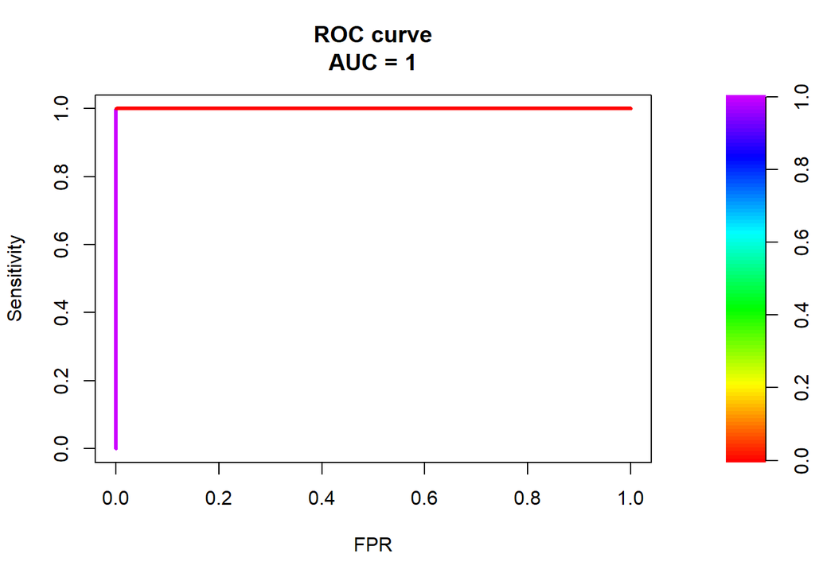

```r
PRROC_obj=roc.curve(scores.class0=prob,weights.class0=as.numeric(as.factor(xytrain$Type))-1,curve=TRUE)
plot(PRROC_obj)
```

The ROC hugs very closely to the top left hand corner and AUC=1, indicating that the model performs extremely well on the training set. However, there may be an issue of overfitting which is a cause of concern if performed on other test sets.

## LDA Visualisation with wheat seeds data

```r
xy=rbind(Q4train,Q4test)
xy=xy[,c(1,3,5,7,8)]
LDA=lda(Type~.,data=xy)
pre=data.frame(predict(LDA)$x)
pre$class=predict(LDA)$class
table(xy$Type)
```

```
##
## Type1 Type2 Type3
##    66    68    65
```

```r
setc=c(mean(pre$LD1[pre$class=='Type1']),mean(pre$LD2[pre$class=='Type1']))
verc=c(mean(pre$LD1[pre$class=='Type2']),mean(pre$LD2[pre$class=='Type2']))
virc=c(mean(pre$LD1[pre$class=='Type3']),mean(pre$LD2[pre$class=='Type3']))
mu=data.frame(LD1=c(setc[1],verc[1],virc[1]),LD2=c(setc[2],verc[2],virc[2]))
mu$class=c("Type1","Type2","Type3")
```

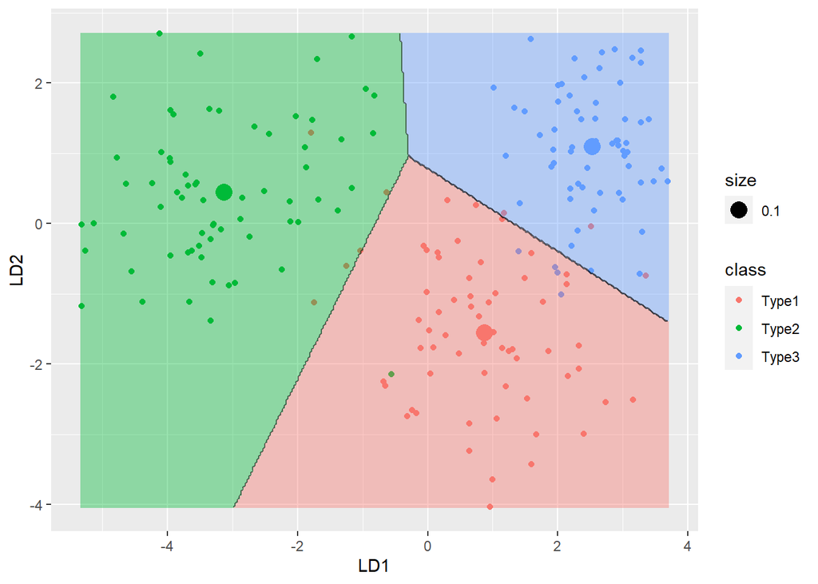

```r
library(ggplot2)
LDA2 <- lda(class ~ LD1 + LD2, data=pre)

ld1lim <- range(c(min(pre$LD1),max(pre$LD1)),mul=0.05)
ld2lim <- range(c(min(pre$LD2),max(pre$LD2)),mul=0.05)
ld1 <- seq(ld1lim[[1]], ld1lim[[2]], length.out=300)
ld2 <- seq(ld2lim[[1]], ld1lim[[2]], length.out=300)
newdat <- expand.grid(list(LD1=ld1,LD2=ld2))
preds <-predict(LDA2,newdata=newdat)

predclass <- preds$class
postprob <- preds$posterior
df <- data.frame(x=newdat$LD1, y=newdat$LD2, class=predclass)
df$classnum <- as.numeric(df$class)
df <- cbind(df,postprob)
df=df[-which(df$y>max(pre$LD2)),]
pre$class=xy$Type
ggplot(pre, aes(x=LD1, y=LD2, colour=class) ) +
geom_point() +
geom_raster(data=df, aes(x=x, y=y, fill = factor(class)),alpha=0.4,show_guide=FALSE) +
geom_contour(data=df, aes(x=x, y=y, z=classnum), colour="black", alpha=0.5, breaks=c(1.5,2.5)) +
geom_point(data=mu, aes(x=LD1, y=LD2, colour=class,cex=0.1))
```

```r
#install.packages('ellipse')
library(ellipse)
dat_ell=pre
for(g in unique(pre$class))
{
exy=pre[pre$class==g,]
ex=exy$LD1
ey=exy$LD2
ell=ellipse(cor(ex,ey),scale=c(sd(ex),sd(ey)),centre=c(mean(ex),mean(ey)))
ell=cbind(ell,rep(g,dim(exy)[1]))
ell=data.frame(ell)
colnames(ell)=colnames(pre)
dat_ell=rbind(dat_ell,ell)
}
```

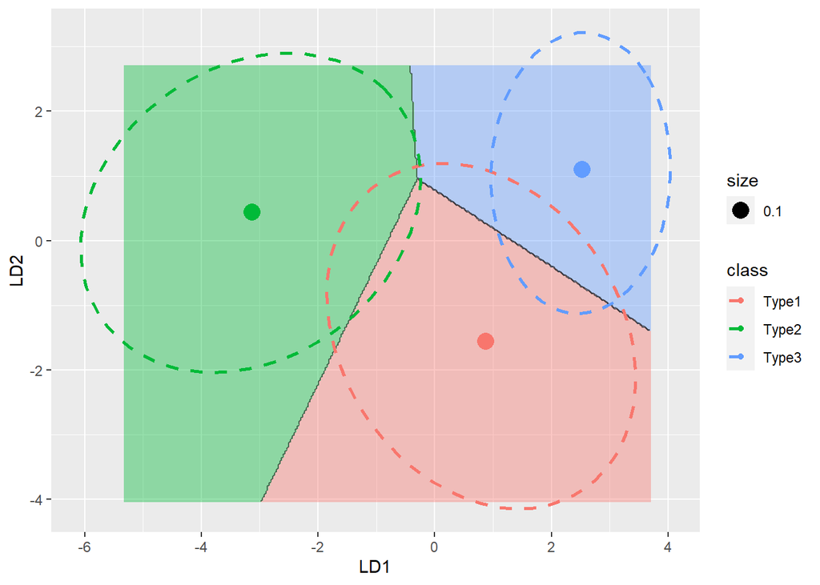

```r
dat_ell=dat_ell[-(1:dim(pre)[1]),]
dat_ell$LD1=as.numeric(dat_ell$LD1)
dat_ell$LD2=as.numeric(dat_ell$LD2)

ggplot(pre, aes(x=LD1, y=LD2, colour=class) ) +
geom_raster(data=df, aes(x=x, y=y, fill = factor(class)),alpha=0.4,show_guide=FALSE) +
geom_contour(data=df, aes(x=x, y=y, z=classnum), colour="black", alpha=0.5, breaks=c(1.5,2.5)) +
geom_point(data=mu, aes(x=LD1, y=LD2, colour=class,cex=0.1)) +
geom_path(data=dat_ell,aes(x=LD1,y=LD2,colour=class),size=1,linetype=2)
```

## Logistic Regression for 1)

```r
#generate data
set.seed(125) #for reproducibility
n=1000 #number of observations
q=5 #number of predictors
ui=0 #mean values for predictors
si=1 #std dev values for predictors
z<- matrix(rnorm(n*q,ui,si),nrow=n)
#generate outcome variables
log_odds= rowSums(z) #generate outcome variable y using the logodds of predictors plus some random noise, and then converting those logodds to probabilities using the logistic function
y= rbinom(n,1,plogis(log_odds))
#y
z=data.frame(z)
#fit logistic regression model
model<- glm(y~z[,1] + z[,2] + z[,3] + z[,4] +z[,5], family=binomial)


#summarise model results
summary(model)
```

```
##
## Call:
## glm(formula = y ~ z[, 1] + z[, 2] + z[, 3] + z[, 4] + z[, 5],
##     family = binomial)
##
## Deviance Residuals:
##      Min        1Q    Median        3Q       Max
## -2.93417  -0.68439   0.07994   0.68895   2.79875
##
## Coefficients:
##             Estimate Std. Error z value Pr(>|z|)
## (Intercept)  0.09471    0.08443   1.122    0.262
## z[, 1]       0.95108    0.09699   9.806   <2e-16 ***
## z[, 2]       1.01880    0.10136  10.051   <2e-16 ***
## z[, 3]       1.03397    0.09981  10.359   <2e-16 ***
## z[, 4]       0.76864    0.09293   8.272   <2e-16 ***
## z[, 5]       1.01751    0.09928  10.249   <2e-16 ***
## ---
## Signif. codes:  0 '***' 0.001 '**' 0.01 '*' 0.05 '.' 0.1 ' ' 1
##
## (Dispersion parameter for binomial family taken to be 1)
##
##     Null deviance: 1386.19  on 999  degrees of freedom
## Residual deviance:  869.96  on 994  degrees of freedom
## AIC: 881.96
##
## Number of Fisher Scoring iterations: 5
```

```r
#Predicting the results
prob=predict(model,z,type="response")
label=rep('',length(prob))
label[prob<0.5]=0
label[prob>=0.5]=1
tab=table(predict=label,real=y)
#calculates the classification accuracy for the test data
logreg=sum(diag(tab))/sum(tab)
tab
```

```
##        real
## predict   0   1
##       0 395 102
##       1 100 403
```

```r
logreg
```

```
## [1] 0.798
```

Accuracy is 79.8%

# ROC curve

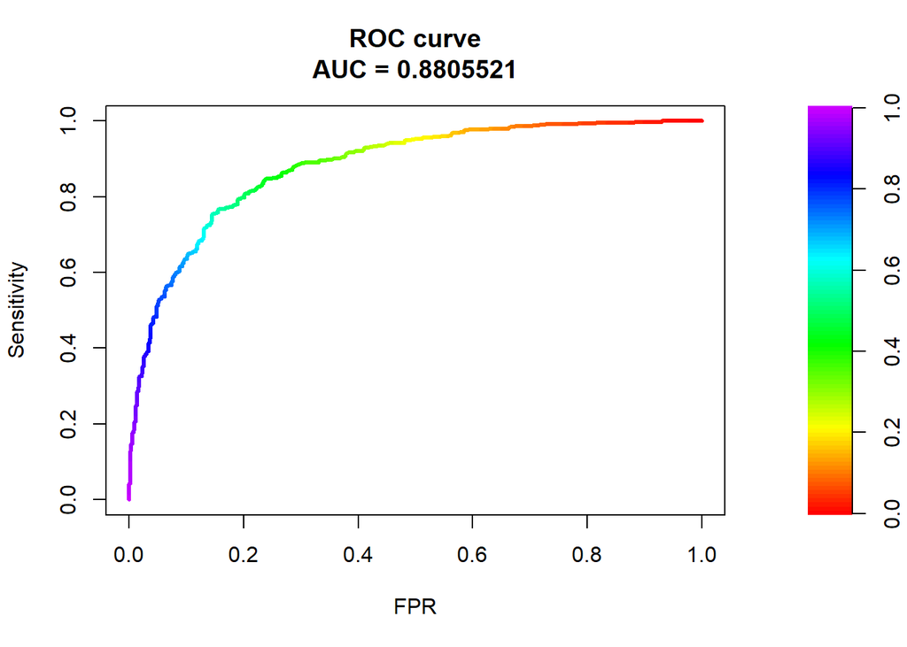

```r
library(PRROC)
PRROC_obj=roc.curve(scores.class0=prob,weights.class0=as.numeric(as.factor(y))-1,curve=TRUE)
plot(PRROC_obj)
```

The AUC for logistic regression is 0.88.

## Naive Bayes for 1)

```r
combined<- data.frame(y,b1=z[,1],b2=z[,2],b3=z[,3],b4=z[,4],b5=z[,5])
#fit naive bayes model
model2=naiveBayes(y~b1+b2+b3+b4+b5, data=combined)
# naive bayes model results
model2
```

```
##
## Naive Bayes Classifier for Discrete Predictors
##
## Call:
## naiveBayes.default(x = X, y = Y, laplace = laplace)
##
## A-priori probabilities:
## Y
##     0     1
## 0.495 0.505
##
## Conditional probabilities:
##    b1
## Y         [,1]      [,2]
##   0 -0.3459164 0.9984681
##   1  0.2187582 0.9360839
##
##    b2
## Y         [,1]      [,2]
##   0 -0.2615119 0.9370550
##   1  0.3448917 0.9424552
##
##    b3
## Y         [,1]      [,2]
##   0 -0.3228681 0.9491512
##   1  0.3339326 0.9332394
##
##    b4
## Y         [,1]      [,2]
##   0 -0.2433136 0.9222818
##   1  0.2209443 0.9778858
##
##    b5
## Y         [,1]      [,2]
##   0 -0.3485137 0.9525573
##   1  0.2531880 0.9484851
```

```r
#prediction
label=predict(model2,combined)
###Confusion table
tab=table(predict=label,real=y);tab
```

```
##        real
## predict   0   1
##       0 400 101
##       1  95 404
```

```r
##Accuracy
sum(diag(tab))/sum(tab)
```

```
## [1] 0.804
```

```r
naivebayes=sum(diag(tab))/sum(tab)
```

The accuracy is 80.4%.

# ROC curve

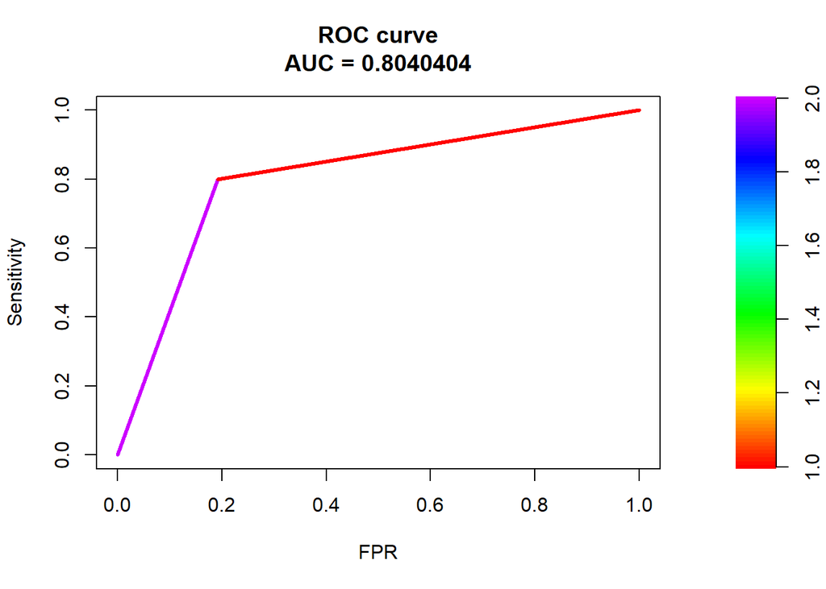

```r
library(PRROC)

PRROC_obj=roc.curve(scores.class0=label,weights.class0=as.numeric(as.factor(y))-1,curve=TRUE)
plot(PRROC_obj)
```

ROC AUC is 0.80404. This implies that Naive Bayes performs worse than Logistic Regression.

## LDA For 1)

```r
model3 <- lda(y~b1+b2+b3+b4+b5, data=combined)
model3$coefficients
```

```r
#Prediction
label=predict(model3)$class
###Confusion table
tab=table(predict=label,real=y);tab
```

```
##        real
## predict   0   1
##       0 397 101
##       1  98 404
```

```r
##Accuracy
sum(diag(tab))/sum(tab)
```

```
## [1] 0.801
```

```r
lda=sum(diag(tab))/sum(tab)
```

The accuracy is 80.1%

# ROC curve

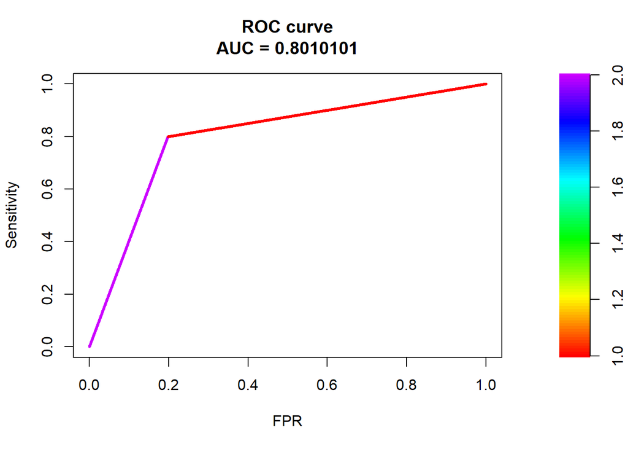

```r
library(PRROC)

PRROC_obj=roc.curve(scores.class0=label,weights.class0=as.numeric(as.factor(y))-1,curve=TRUE)
plot(PRROC_obj)
```

The AUC is 0.801.

## QDA For 1)

```r
model4 <- qda(y~b1+b2+b3+b4+b5, data=combined)
model4
```

```
## Call:
## qda(y ~ b1 + b2 + b3 + b4 + b5, data = combined)
##
## Prior probabilities of groups:
##     0     1
## 0.495 0.505
##
## Group means:
##           b1         b2         b3         b4         b5
## 0 -0.3459164 -0.2615119 -0.3228681 -0.2433136 -0.3485137
## 1  0.2187582  0.3448917  0.3339326  0.2209443  0.2531880
```

```r
#Prediction
label=predict(model4)$class
###Confusion table
tab=table(predict=label,real=y);tab
```

```
##        real
## predict   0   1
##       0 399 101
##       1  96 404
```

```r
##Accuracy
sum(diag(tab))/sum(tab)
```

```
## [1] 0.803
```

```r
qda=sum(diag(tab))/sum(tab)
qda
```

```
## [1] 0.803
```

The accuracy is 80.3%

# ROC curve

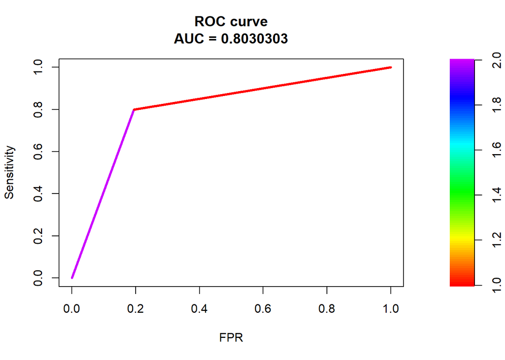

```r
library(PRROC)

PRROC_obj=roc.curve(scores.class0=label,weights.class0=as.numeric(as.factor(y))-1,curve=TRUE)
plot(PRROC_obj)
```

The AUC is 0.803.

## Comparing accuracy of all models

```r
data.frame(logreg,naivebayes,lda,qda)
```

```
##   logreg naivebayes   lda   qda
## 1  0.798      0.804 0.801 0.803
```

The accuracy of the logistic regression model performs the worst, while the Naive Bayes performs the best. The accuracy of all models only differ by at most 0.6%, which means they produce similar results for case 1.

## Logistic Regression for 2)

```r
#generate data
set.seed(125) #for reproducibility
n=1000 #number of observations
q=5 #number of predictors
ui=0 #mean values for predictors
si=1 #std dev values for predictors
z<- matrix(rnorm(n*q,ui,si),nrow=n)
#generate outcome variables
#let b1=1, b2=2, b3=3, b4=4, b5=4
xb<- z[,1] + 2*z[,2] + 3*z[,3] + 4*z[,4] + 5*z[,5]
p <- 1/(1 + exp(-xb))
y= rbinom(n,1,prob=p)
#y

#fit logistic regression model
model<- glm(y~z[,1] + z[,2] + z[,3] + z[,4] +z[,5], family=binomial)



#summarise model results
summary(model)
```

```
##
## Call:
## glm(formula = y ~ z[, 1] + z[, 2] + z[, 3] + z[, 4] + z[, 5],
##     family = binomial)
##
## Deviance Residuals:
##      Min        1Q    Median        3Q       Max
## -2.83297  -0.11619  -0.00023   0.09567   2.86046
##
## Coefficients:
##             Estimate Std. Error z value Pr(>|z|)
## (Intercept)   0.1235     0.1420   0.870    0.384
## z[, 1]        0.7478     0.1549   4.829 1.38e-06 ***
## z[, 2]        1.8512     0.2043   9.062  < 2e-16 ***
## z[, 3]        2.9043     0.2671  10.874  < 2e-16 ***
## z[, 4]        3.8651     0.3370  11.468  < 2e-16 ***
## z[, 5]        5.0122     0.4187  11.971  < 2e-16 ***
## ---
## Signif. codes:  0 '***' 0.001 '**' 0.01 '*' 0.05 '.' 0.1 ' ' 1
##
## (Dispersion parameter for binomial family taken to be 1)
##
##     Null deviance: 1386.10  on 999  degrees of freedom
## Residual deviance:  329.76  on 994  degrees of freedom
## AIC: 341.76
##
## Number of Fisher Scoring iterations: 8
```

```r
#Predicting the results
z=data.frame(z)
prob=predict(model,z,type="response")
label=rep('',length(prob))
label[prob<0.5]=0
label[prob>=0.5]=1
tab=table(predict=label,real=y)
#calculates the classification accuracy for the test data
logreg=sum(diag(tab))/sum(tab)
tab
```

```
##        real
## predict   0   1
##       0 470  31
##       1  37 462
```

```r
logreg
```

```
## [1] 0.932
```

## Naive Bayes for 2)

```r
combined<- data.frame(y,b1=z[,1],b2=z[,2],b3=z[,3],b4=z[,4],b5=z[,5])
#fit naive bayes model
model2=naiveBayes(y~b1+b2+b3+b4+b5, data=combined)
# naive bayes model results
model2
```

```
##
## Naive Bayes Classifier for Discrete Predictors
##
## Call:
## naiveBayes.default(x = X, y = Y, laplace = laplace)
##
## A-priori probabilities:
## Y
##     0     1
## 0.507 0.493
##
## Conditional probabilities:
##    b1
## Y         [,1]     [,2]
##   0 -0.1344809 1.006812
##   1  0.0150631 1.003367
##
##    b2
## Y         [,1]      [,2]
##   0 -0.1721583 0.9550046
##   1  0.2677609 0.9705959
##
##    b3
## Y         [,1]      [,2]
##   0 -0.3421204 0.9205555
##   1  0.3697187 0.9417773
##
##    b4
## Y         [,1]      [,2]
##   0 -0.4268847 0.8504438
##   1  0.4210288 0.9132729
##
##    b5
## Y         [,1]      [,2]
##   0 -0.5647123 0.8481506
##   1  0.4901720 0.8434524
```

```r
#prediction
label=predict(model2,combined)
###Confusion table
tab=table(predict=label,real=y);tab
```

```
##        real
## predict   0   1
##       0 471  38
##       1  36 455
```

```r
##Accuracy
naivebayes=sum(diag(tab))/sum(tab)
naivebayes
```

```
## [1] 0.926
```

## LDA For 2)

```r
model3 <- lda(y~b1+b2+b3+b4+b5, data=combined)
model3$coefficients
```

```r
#Prediction
label=predict(model3)$class
###Confusion table
tab=table(predict=label,real=y);tab
```

```
##        real
## predict   0   1
##       0 476  36
##       1  31 457
```

```r
##Accuracy
lda=sum(diag(tab))/sum(tab)
lda
```

```
## [1] 0.933
```

## QDA For 2)

```r
model4 <- qda(y~b1+b2+b3+b4+b5, data=combined)
model4
```

```
## Call:
## qda(y ~ b1 + b2 + b3 + b4 + b5, data = combined)
##
## Prior probabilities of groups:
##     0     1
## 0.507 0.493
##
## Group means:
##           b1         b2         b3         b4         b5
## 0 -0.1344809 -0.1721583 -0.3421204 -0.4268847 -0.5647123
## 1  0.0150631  0.2677609  0.3697187  0.4210288  0.4901720
```

```r
#Prediction
label=predict(model4)$class
###Confusion table
tab=table(predict=label,real=y);tab
```

```
##        real
## predict   0   1
##       0 472  36
##       1  35 457
```

```r
##Accuracy
sum(diag(tab))/sum(tab)
```

```
## [1] 0.929
```

```r
qda=sum(diag(tab))/sum(tab)
qda
```

```
## [1] 0.929
```

## Comparing accuracy of all models

```r
data.frame(logreg,naivebayes,lda,qda)
```

```
##   logreg naivebayes   lda   qda
## 1  0.932      0.926 0.933 0.929
```

LDA performs the best, while Naive Bayes performs the worst.

## Logistic Regression for 3)

```r
#generate data
set.seed(125) #for reproducibility
n=1000 #number of observations
q=5 #number of predictors
ui=0 #mean values for predictors
si=1 #std dev values for predictors
z<- matrix(rnorm(n*q,ui,si),nrow=n)
#generate outcome variables
#let b1=1, b2=2, b3=3, b4=4, b5=4
xb<- z[,1] + 2*z[,2] + 3*z[,3] + 4*z[,4] + 5*z[,5]
p <- (tanh(xb)+1)/2
y= rbinom(n,1,prob=p)
#y

#fit logistic regression model
model<- glm(y~z[,1] + z[,2] + z[,3] + z[,4] +z[,5], family=binomial)
#summarise model results
summary(model)
```

```
##
## Call:
## glm(formula = y ~ z[, 1] + z[, 2] + z[, 3] + z[, 4] + z[, 5],
##     family = binomial)
##
## Deviance Residuals:
##     Min       1Q   Median       3Q      Max
## -2.8638  -0.0044   0.0000   0.0033   3.2236
##
## Coefficients:
##             Estimate Std. Error z value Pr(>|z|)
## (Intercept)   0.1954     0.2047   0.955     0.34
## z[, 1]        2.2957     0.3657   6.278 3.44e-10 ***
## z[, 2]        4.4005     0.5732   7.678 1.62e-14 ***
## z[, 3]        6.4204     0.7991   8.034 9.43e-16 ***
## z[, 4]        9.0717     1.1085   8.184 2.75e-16 ***
## z[, 5]       11.1092     1.3435   8.269  < 2e-16 ***
## ---
## Signif. codes:  0 '***' 0.001 '**' 0.01 '*' 0.05 '.' 0.1 ' ' 1
##
## (Dispersion parameter for binomial family taken to be 1)
##
##     Null deviance: 1386.04  on 999  degrees of freedom
## Residual deviance:  156.42  on 994  degrees of freedom
## AIC: 168.42
##
## Number of Fisher Scoring iterations: 10
```

```r
#Predicting the results
z=data.frame(z)
prob=predict(model,z,type="response")
label=rep('',length(prob))
label[prob<0.5]=0
label[prob>=0.5]=1
tab=table(predict=label,real=y)
#calculates the classification accuracy for the test data
logreg=sum(diag(tab))/sum(tab)
tab
```

```
##        real
## predict   0   1
##       0 490  16
##       1  18 476
```

```r
logreg
```

```
## [1] 0.966
```

## Naive Bayes for 3)

```r
combined<- data.frame(y,b1=z[,1],b2=z[,2],b3=z[,3],b4=z[,4],b5=z[,5])
#fit naive bayes model
model2=naiveBayes(y~b1+b2+b3+b4+b5, data=combined)
# naive bayes model results
model2
```

```
##
## Naive Bayes Classifier for Discrete Predictors
##
## Call:
## naiveBayes.default(x = X, y = Y, laplace = laplace)
##
## A-priori probabilities:
## Y
##     0     1
## 0.508 0.492
##
## Conditional probabilities:
##    b1
## Y          [,1]      [,2]
##   0 -0.15641398 1.0260571
##   1  0.03801336 0.9790174
##
##    b2
## Y         [,1]      [,2]
##   0 -0.1851585 0.9490595
##   1  0.2820781 0.9701534
##
##    b3
## Y         [,1]      [,2]
##   0 -0.3440463 0.9200025
##   1  0.3731541 0.9403145
##
##    b4
## Y         [,1]      [,2]
##   0 -0.4459297 0.8326891
##   1  0.4424165 0.9107344
##
##    b5
## Y         [,1]      [,2]
##   0 -0.5621436 0.8571549
##   1  0.4896639 0.8359866
```

```r
#prediction
label=predict(model2,combined)
###Confusion table
tab=table(predict=label,real=y);tab
```

```
##        real
## predict   0   1
##       0 492  20
##       1  16 472
```

```r
##Accuracy
naivebayes=sum(diag(tab))/sum(tab)
naivebayes
```

```
## [1] 0.964
```

## LDA For 3)

```r
model3 <- lda(y~b1+b2+b3+b4+b5, data=combined)
model3$coefficients
```

```r
#Prediction
label=predict(model3)$class
###Confusion table
tab=table(predict=label,real=y);tab
```

```
##        real
## predict   0   1
##       0 490  21
##       1  18 471
```

```r
##Accuracy
lda=sum(diag(tab))/sum(tab)
lda
```

```
## [1] 0.961
```

## QDA For 3)

```r
model4 <- qda(y~b1+b2+b3+b4+b5, data=combined)
model4
```

```
## Call:
## qda(y ~ b1 + b2 + b3 + b4 + b5, data = combined)
##
## Prior probabilities of groups:
##     0     1
## 0.508 0.492
##
## Group means:
##            b1         b2         b3         b4         b5
## 0 -0.15641398 -0.1851585 -0.3440463 -0.4459297 -0.5621436
## 1  0.03801336  0.2820781  0.3731541  0.4424165  0.4896639
```

```r
#Prediction
label=predict(model4)$class
###Confusion table
tab=table(predict=label,real=y);tab
```

```
##        real
## predict   0   1
##       0 490  20
##       1  18 472
```

```r
##Accuracy
sum(diag(tab))/sum(tab)
```

```
## [1] 0.962
```

```r
qda=sum(diag(tab))/sum(tab)
qda
```

```
## [1] 0.962
```

## Comparing accuracy of all models

```r
data.frame(logreg,naivebayes,lda,qda)
```

```
##   logreg naivebayes   lda   qda
## 1  0.966      0.964 0.961 0.962
```

Logistic regression performs the best, while LDA performs the worst.

## Logistic Regression for 4)

```r
#generate data
set.seed(125) #for reproducibility
n=1000 #number of observations
q=5 #number of predictors
ui=0 #mean values for predictors
si=1 #std dev values for predictors
z<- matrix(rnorm(n*q,ui,si),nrow=n)
#generate outcome variables
#let b1=1, b2=2, b3=3, b4=4, b5=4
xb<- z[,1] + 2*z[,2] + 3*z[,3] + 4*z[,4] + 5*z[,5]
p <- (atan(xb)+ (pi/2))/pi
y= rbinom(n,1,prob=p)
#y

#fit logistic regression model
model<- glm(y~z[,1] + z[,2] + z[,3] + z[,4] +z[,5], family=binomial)



#summarise model results
summary(model)
```

```
##
## Call:
## glm(formula = y ~ z[, 1] + z[, 2] + z[, 3] + z[, 4] + z[, 5],
##     family = binomial)
##
## Deviance Residuals:
##     Min       1Q   Median       3Q      Max
## -3.6770  -0.4295  -0.0190   0.3869   3.2356
##
## Coefficients:
##             Estimate Std. Error z value Pr(>|z|)
## (Intercept)  0.04733    0.10215   0.463  0.64309
## z[, 1]       0.27910    0.10272   2.717  0.00659 **
## z[, 2]       0.85066    0.11548   7.366 1.76e-13 ***
## z[, 3]       1.48085    0.13278  11.153  < 2e-16 ***
## z[, 4]       1.90806    0.15014  12.708  < 2e-16 ***
## z[, 5]       2.38991    0.17308  13.808  < 2e-16 ***
## ---
## Signif. codes:  0 '***' 0.001 '**' 0.01 '*' 0.05 '.' 0.1 ' ' 1
##
## (Dispersion parameter for binomial family taken to be 1)
##
##     Null deviance: 1386.10  on 999  degrees of freedom
## Residual deviance:  619.28  on 994  degrees of freedom
## AIC: 631.28
##
## Number of Fisher Scoring iterations: 6
```

```r
#Predicting the results
z=data.frame(z)
prob=predict(model,z,type="response")
label=rep('',length(prob))
label[prob<0.5]=0
label[prob>=0.5]=1
tab=table(predict=label,real=y)
#calculates the classification accuracy for the test data
logreg=sum(diag(tab))/sum(tab)
logreg
```

```
## [1] 0.896
```

## Naive Bayes for 4)

```r
combined<- data.frame(y,b1=z[,1],b2=z[,2],b3=z[,3],b4=z[,4],b5=z[,5])
#fit naive bayes model
model2=naiveBayes(y~b1+b2+b3+b4+b5, data=combined)
# naive bayes model results
model2
```

```
##
## Naive Bayes Classifier for Discrete Predictors
##
## Call:
## naiveBayes.default(x = X, y = Y, laplace = laplace)
##
## A-priori probabilities:
## Y
##     0     1
## 0.507 0.493
##
## Conditional probabilities:
##    b1
## Y            [,1]      [,2]
##   0 -0.1204959158 0.9929179
##   1  0.0006809354 1.0194221
##
##    b2
## Y         [,1]      [,2]
##   0 -0.1472018 0.9618831
##   1  0.2420957 0.9745876
##
##    b3
## Y         [,1]      [,2]
##   0 -0.3242690 0.9298048
##   1  0.3513603 0.9459737
##
##    b4
## Y         [,1]      [,2]
##   0 -0.4003802 0.8645099
##   1  0.3937716 0.9241793
##
##    b5
## Y         [,1]      [,2]
##   0 -0.5205441 0.8739853
##   1  0.4447495 0.8704040
```

```r
#prediction
label=predict(model2,combined)
###Confusion table
tab=table(predict=label,real=y);tab
```

```
##        real
## predict   0   1
##       0 457  56
##       1  50 437
```

```r
##Accuracy
naivebayes=sum(diag(tab))/sum(tab)
naivebayes
```

```
## [1] 0.894
```

## LDA For 4)

```r
model3 <- lda(y~b1+b2+b3+b4+b5, data=combined)
model3$coefficients
```

```r
#Prediction
label=predict(model3)$class
###Confusion table
tab=table(predict=label,real=y);tab
```

```
##        real
## predict   0   1
##       0 462  57
##       1  45 436
```

```r
##Accuracy
lda=sum(diag(tab))/sum(tab)
lda
```

```
## [1] 0.898
```

## QDA For 4)

```r
model4 <- qda(y~b1+b2+b3+b4+b5, data=combined)
model4
```

```
## Call:
## qda(y ~ b1 + b2 + b3 + b4 + b5, data = combined)
##
## Prior probabilities of groups:
##     0     1
## 0.507 0.493
##
## Group means:
##              b1         b2         b3         b4         b5
## 0 -0.1204959158 -0.1472018 -0.3242690 -0.4003802 -0.5205441
## 1  0.0006809354  0.2420957  0.3513603  0.3937716  0.4447495
```

```r
#Prediction
label=predict(model4)$class
###Confusion table
tab=table(predict=label,real=y);tab
```

```
##        real
## predict   0   1
##       0 459  55
##       1  48 438
```

```r
##Accuracy
sum(diag(tab))/sum(tab)
```

```
## [1] 0.897
```

```r
qda=sum(diag(tab))/sum(tab)
qda
```

```
## [1] 0.897
```

## Comparing accuracy of all models

```r
data.frame(logreg,naivebayes,lda,qda)
```

```
##   logreg naivebayes   lda   qda
## 1  0.896      0.894 0.898 0.897
```

LDA perfoms the best, while naive bayes performs the worst.

## Logistic Regression for 5)

```r
#generate data
set.seed(125) #for reproducibility
n=1000 #number of observations
q=2 #number of predictors
p=0.86 #probability
z<- matrix(rbinom(n*q,1,p),nrow=n)
#generate outcome variables
#let b1=1, b2=1
y <- (z[,1] + z[,2] )%%2


#fit logistic regression model
model<- glm(y~z[,1] + z[,2] , family=binomial)


#summarise model results
summary(model)
```

```
##
## Call:
## glm(formula = y ~ z[, 1] + z[, 2], family = binomial)
##
## Deviance Residuals:
##     Min       1Q   Median       3Q      Max
## -3.8633  -0.2069  -0.2069  -0.2069   0.5719
##
## Coefficients:
##             Estimate Std. Error z value Pr(>|z|)
## (Intercept)   7.4621     0.4572   16.32   <2e-16 ***
## z[, 1]       -5.7342     0.3682  -15.57   <2e-16 ***
## z[, 2]       -5.5612     0.3706  -15.01   <2e-16 ***
## ---
## Signif. codes:  0 '***' 0.001 '**' 0.01 '*' 0.05 '.' 0.1 ' ' 1
##
## (Dispersion parameter for binomial family taken to be 1)
##
##     Null deviance: 1076.13  on 999  degrees of freedom
## Residual deviance:  340.06  on 997  degrees of freedom
## AIC: 346.06
##
## Number of Fisher Scoring iterations: 6
```

```r
#Predicting the results
z=data.frame(z)
prob=predict(model,z,type="response")
label=rep('',length(prob))
label[prob<0.5]=0
label[prob>=0.5]=1
tab=table(predict=label,real=y)
#calculates the classification accuracy for the test data
logreg=sum(diag(tab))/sum(tab)
tab
```

```
##        real
## predict   0   1
##       0 755   0
##       1  16 229
```

```r
logreg
```

```
## [1] 0.984
```

## Naive Bayes for 5)

```r
combined<- data.frame(y,b1=z[,1],b2=z[,2])
#fit naive bayes model
model2=naiveBayes(y~b1+b2, data=combined)
# naive bayes model results
model2
```

```
##
## Naive Bayes Classifier for Discrete Predictors
##
## Call:
## naiveBayes.default(x = X, y = Y, laplace = laplace)
##
## A-priori probabilities:
## Y
##     0     1
## 0.771 0.229
##
## Conditional probabilities:
##    b1
## Y        [,1]      [,2]
##   0 0.9792477 0.1426464
##   1 0.4628821 0.4997126
##
##    b2
## Y        [,1]      [,2]
##   0 0.9792477 0.1426464
##   1 0.5371179 0.4997126
```

```r
#prediction
label=predict(model2,combined)
###Confusion table
tab=table(predict=label,real=y);tab
```

```
##        real
## predict   0   1
##       0 755   0
##       1  16 229
```

```r
##Accuracy
naivebayes=sum(diag(tab))/sum(tab)
naivebayes
```

```
## [1] 0.984
```

## LDA For 5)

```r
model3 <- lda(y~b1+b2, data=combined)
model3$coefficients
```

```r
#Prediction
label=predict(model3)$class
###Confusion table
tab=table(predict=label,real=y);tab
```

```
##        real
## predict   0   1
##       0 755   0
##       1  16 229
```

```r
##Accuracy
lda=sum(diag(tab))/sum(tab)
lda
```

```
## [1] 0.984
```

## QDA For 5)

QDA cannot be performed as the zis are values of 0 and It assumes real values (and not factors) in the explanatory variables. Thus, there would be an error “Error in qda.default(x, grouping, …) : rank deficiency in group 0” if QDA is performed in R.

## Comparing accuracy of all models

```r
data.frame(logreg,naivebayes,lda)
```

```
##   logreg naivebayes   lda
## 1  0.984      0.984 0.984
```

All models have the same accuracy, performing equally.

## Logistic Regression for 6) Gudermannian function

Relationship: f(Y) is a Gudermannian function, where P(Y=1)= 2*arctan(tanh(x/2))

We shall let P(Y=1)= (pi/2 +2*arctan(tanh(2z1 + 3z2/2)))/pi where z1,z2 are i.i.d from N(ui,si)

```r
#generate data
set.seed(125) #for reproducibility
n=1000 #number of observations
q=2 #number of predictors
ui=0 #mean values for predictors
si=1 #std dev values for predictors
z<- matrix(rnorm(n*q,ui,si),nrow=n)
#generate outcome variables
#let b1=2, b2=3
p <- (2*atan(tanh((2*z[,1]+3*z[,2])/2)) + pi/2)/pi

y= rbinom(n,1,prob=p)
#y

#fit logistic regression model
model<- glm(y~z[,1] + z[,2], family=binomial)



#summarise model results
summary(model)
```

```
##
## Call:
## glm(formula = y ~ z[, 1] + z[, 2], family = binomial)
##
## Deviance Residuals:
##      Min        1Q    Median        3Q       Max
## -2.70993  -0.41202  -0.01301   0.33982   2.90202
##
## Coefficients:
##             Estimate Std. Error z value Pr(>|z|)
## (Intercept) -0.04949    0.10488  -0.472    0.637
## z[, 1]       2.22876    0.17099  13.034   <2e-16 ***
## z[, 2]       3.47065    0.23549  14.738   <2e-16 ***
## ---
## Signif. codes:  0 '***' 0.001 '**' 0.01 '*' 0.05 '.' 0.1 ' ' 1
##
## (Dispersion parameter for binomial family taken to be 1)
##
##     Null deviance: 1385.72  on 999  degrees of freedom
## Residual deviance:  582.56  on 997  degrees of freedom
## AIC: 588.56
##
## Number of Fisher Scoring iterations: 7
```

```r
#Predicting the results
z=data.frame(z)
prob=predict(model,z,type="response")
label=rep('',length(prob))
label[prob<0.5]=0
label[prob>=0.5]=1
tab=table(predict=label,real=y)
#calculates the classification accuracy for the test data
logreg=sum(diag(tab))/sum(tab)
tab
```

```
##        real
## predict   0   1
##       0 453  71
##       1  59 417
```

```r
logreg
```

```
## [1] 0.87
```

## Naive Bayes for 6)

```r
combined<- data.frame(y,b1=z[,1],b2=z[,2])
#fit naive bayes model
model2=naiveBayes(y~b1+b2, data=combined)
# naive bayes model results
model2
```

```
##
## Naive Bayes Classifier for Discrete Predictors
##
## Call:
## naiveBayes.default(x = X, y = Y, laplace = laplace)
##
## A-priori probabilities:
## Y
##     0     1
## 0.512 0.488
##
## Conditional probabilities:
##    b1
## Y         [,1]      [,2]
##   0 -0.4562249 0.9376096
##   1  0.3541628 0.9068663
##
##    b2
## Y         [,1]      [,2]
##   0 -0.5372350 0.7626248
##   1  0.6552996 0.8116552
```

```r
#prediction
label=predict(model2,combined)
###Confusion table
tab=table(predict=label,real=y);tab
```

```
##        real
## predict   0   1
##       0 455  82
##       1  57 406
```

```r
##Accuracy
naivebayes=sum(diag(tab))/sum(tab)
naivebayes
```

```
## [1] 0.861
```

## LDA For 6)

```r
model3 <- lda(y~b1+b2, data=combined)
model3$coefficients
```

```r
#Prediction
label=predict(model3)$class
###Confusion table
tab=table(predict=label,real=y);tab
```

```
##        real
## predict   0   1
##       0 458  72
##       1  54 416
```

```r
##Accuracy
lda=sum(diag(tab))/sum(tab)
lda
```

```
## [1] 0.874
```

## QDA For 6)

```r
model4 <- qda(y~b1+b2, data=combined)
model4
```

```
## Call:
## qda(y ~ b1 + b2, data = combined)
##
## Prior probabilities of groups:
##     0     1
## 0.512 0.488
##
## Group means:
##           b1         b2
## 0 -0.4562249 -0.5372350
## 1  0.3541628  0.6552996
```

```r
#Prediction
label=predict(model4)$class
###Confusion table
tab=table(predict=label,real=y);tab
```

```
##        real
## predict   0   1
##       0 459  74
##       1  53 414
```

```r
##Accuracy
sum(diag(tab))/sum(tab)
```

```
## [1] 0.873
```

```r
qda=sum(diag(tab))/sum(tab)
qda
```

```
## [1] 0.873
```

## Comparing accuracy of all models

```r
data.frame(logreg,naivebayes,lda,qda)
```

```
##   logreg naivebayes   lda   qda
## 1   0.87      0.861 0.874 0.873
```

LDA performs the best, while Naive Bayes performs the worst.